# Welcome to The Summer School 2022: Introduction to R

10 July 2022

## Welcome to the Summer School 2022

## The Team

- Stephan Lewandowsky
- Klaus Oberauer
- Gordon Brown
- Chris Donkin
- Cas Ludwig
- Joachim Vandekerckhove
- Jana Jarecki
- Laura Fontanesi
- Michael Nunez
- Beatrice Kuhlmann

## Why R?

## The advantages of R

- R is free
- R is powerful
- R is “expert-friendly”
- R has numerous packages for a broad range of problems
- These slides were written in R (sort of)

## The problem with R

[figure not shown]

## Command line exercises (1)

- Creating and manipulating vectors and matrices
  1. Create a vector **a** = [1 0 -1 0 1 2 3] and a vector **b** = [1 1 0 0 -1 -2 -1].
  2. Multiply all elements in **b** with 2, keep the result as the new vector **b**.
  3. Compute the dot product of **a** and **b**.
  4. Compute matrix **C** as the outer product of **a** and **b**.

## Command line exercises (1) (a)

Create a vector **a** = [1 0 -1 0 1 2 3] and a vector **b** = [1 1 0 0 -1 -2 -1].

```r
#problem 1a
a <- c(1, 0, -1, 0, 1, 2, 3)
b <- c(1, 1, 0, 0, -1, -2, -1)

print(a)
```

```
## [1]  1  0 -1  0  1  2  3
```

```r
print(b)
```

```
## [1]  1  1  0  0 -1 -2 -1
```

## Command line exercises (1) (b)

Multiply all elements in **b** with 2, keep the result as the new vector **b**.

```r
#problem 1b
print(b)
```

```
## [1]  1  1  0  0 -1 -2 -1
```

```r
b <- b * 2
print(b)
```

```
## [1]  2  2  0  0 -2 -4 -2
```

## Command line exercises (1) (c)

Compute the dot product of **a** and **b**.

```r
dp <- a %*% b  #note this is the new b

print(dp)
```

```
##      [,1]
## [1,]  -14
```

```r
drop(dp)
```

```
## [1] -14
```

## Command line exercises (1) (d)

Compute matrix **C** as the outer product of **a** and **b**.

```r
C <- outer(a,b)

print(C)
```

```
##      [,1] [,2] [,3] [,4] [,5] [,6] [,7]
## [1,]    2    2    0    0   -2   -4   -2
## [2,]    0    0    0    0    0    0    0
## [3,]   -2   -2    0    0    2    4    2
## [4,]    0    0    0    0    0    0    0
## [5,]    2    2    0    0   -2   -4   -2
## [6,]    4    4    0    0   -4   -8   -4
## [7,]    6    6    0    0   -6  -12   -6
```

## Command line exercises (2)

- Indexing vectors and matrices
  1. Compute vector **d** as the 3rd row of matrix **C**
  2. Compute *e* as the 7th row, 6th column entry of **C**.
  3. Compute vector **f** containing entries [3, 1], [6, 5], and [1, 7], where the first value in each pair of brackets denotes the row and the second value denotes the column of the requested entry.

## Command line exercises (2) (a)

Compute vector **d** as the 3rd row of matrix **C**

```r
d <- C[3,]
print(d)
```

```
## [1] -2 -2  0  0  2  4  2
```

## Command line exercises (2) (b)

Compute *e* as the 7th row, 6th column entry of **C**.

```r
e <- C[7, 6]
print(e)
```

```
## [1] -12
```

## Command line exercises (2) (c)

Compute vector **f** containing entries [3, 1], [6, 5], and [1, 7], where the first value in each pair of brackets denotes the row and the second value denotes the column of the requested entry.

```r
f <- c(C[3,1], C[6,5], C[1,7])
print(f)
```

```
## [1] -2 -4 -2
```

## Command line exercises (3)

- Logical indexing: Given **x** = [7 6 1 2 0 -1 4 3 -2 0], what are the commands that will execute the following operations:
  1. Sets the negative values of **x** to zero.
  2. Extracts the values of **x** greater than 3 in a vector **y**.
  3. Adds 3 to the values of **x** that are even.
  4. Sets the values of **x** that are less than the mean to zero.
  5. Sets the values of **x** that are greater than the mean to their difference with the mean.

## Command line exercises (3) (a)

Set the negative values of **x** to zero.

```r
x <- c(7, 6, 1, 2, 0, -1, 4, 3, -2, 0)

g <- (x <  0)
print(g)
```

```
##  [1] FALSE FALSE FALSE FALSE FALSE  TRUE FALSE FALSE  TRUE FALSE
```

```r
x[g] <- 0
print(x)
```

```
##  [1] 7 6 1 2 0 0 4 3 0 0
```

## Command line exercises (3) (b)

Extract the values of **x** greater than 3 in a vector **y**.

```r
x <- c(7, 6, 1, 2, 0, -1, 4, 3, -2, 0)

y <- x[x>3]
print(y)
```

```
## [1] 7 6 4
```

## Command line exercises (3) (c)

Add 3 to the values of **x** that are even.

```r
evenxs <- x %% 2 ==0  # %% obtains modulus (remainder)
print(evenxs)
```

```
##  [1] FALSE  TRUE FALSE  TRUE  TRUE FALSE  TRUE FALSE  TRUE  TRUE
```

```r
x[evenxs] <- x[evenxs] + 3
print(x)
```

```
##  [1]  7  9  1  5  3 -1  7  3  1  3
```

## Command line exercises (3) (d)

Set the values of **x** that are less than the mean to zero.

```r
x <- c(7, 6, 1, 2, 0, -1, 4, 3, -2, 0)
x[x < mean(x)] <- 0
print(x)
```

```
##  [1] 7 6 0 2 0 0 4 3 0 0
```

## Command line exercises (3) (e)

Set the values of **x** that are greater than the mean to their difference with the mean.

```r
x <- c(7, 6, 1, 2, 0, -1, 4, 3, -2, 0)
mx <- mean(x)
x[x > mx] <- x[x > mx] - mx
print(x)
```

```
##  [1]  5  4  1  2  0 -1  2  1 -2  0
```

## Command line exercises (4)

- Generating and plotting curves
  1. Compute the logistic function \(y = 1/(1+exp(-(x-a)*b))\) for values of *x* from -3 to 3 in steps of 0.1. Use *b* = 1 and *a* = 0.
  2. Plot *y* as a function of *x*.
  3. Do the same for *a* = 1, what happens?
  4. Do the same for *a* = 0 and *b* = 3, what happens?

## Command line exercises (4) (a & b)

1. Compute the logistic function \(y = 1/(1+exp(-(x-a)*b))\) for values of *x* from -3 to 3 in steps of 0.1. Use *b* = 1 and *a* = 0.
2. Plot *y* as a function of *x*.

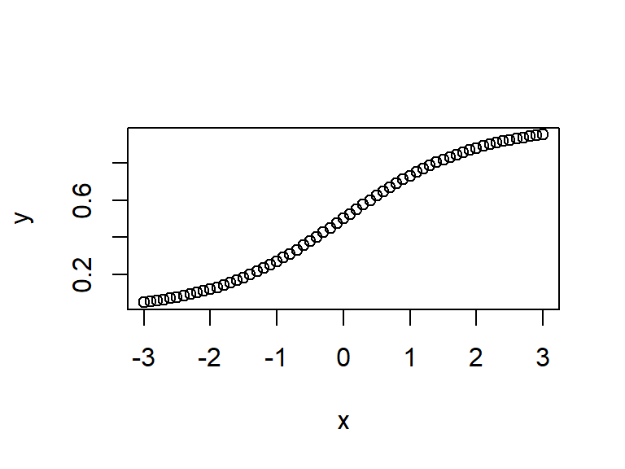

```r
x<-seq(from=-3,to=3,by=0.1)
b <- 1
a <- 0
y <- 1/(1+exp(-(x-a)*b))
plot(x,y)
```

## Command line exercises (4) (c)

Do the same for *a* = 1, what happens?

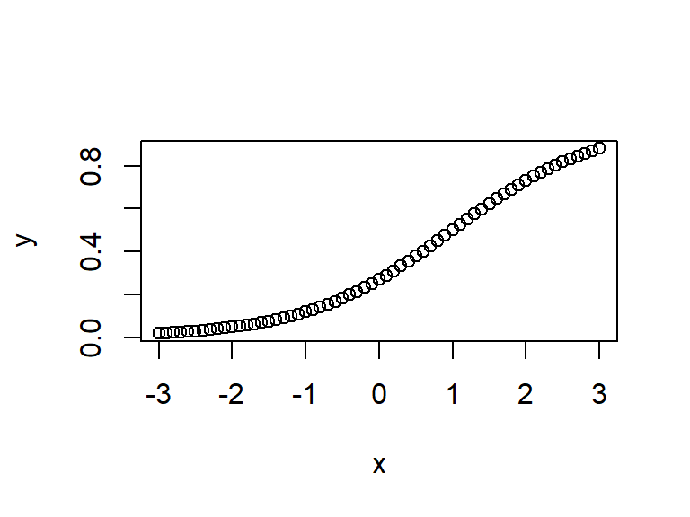

```r
a <- 1
y <- 1/(1+exp(-(x-a)*b))
plot(x,y)
```

## Command line exercises (4) (d)

Do the same for *a* = 0 and *b* = 3, what happens?

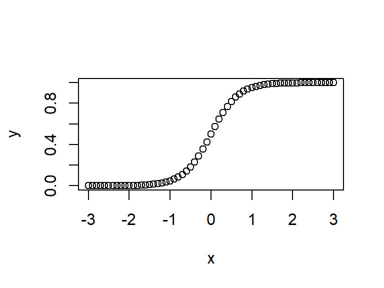

```r
a <- 0
b <- 3
y <- 1/(1+exp(-(x-a)*b))
plot(x,y)
```

## Command line exercises (5) (a & b)

1. Generate a vector **m** with 100 values drawn at random from a normal (Gaussian) distribution with mean 0.5 and standard deviation 0.15.
2. Generate a vector **t** with 100 values drawn at random from an exponential distribution with mean = 0.4.

```r
m <- rnorm(100, 0.5, 0.15)

t <- rexp(100,1/.4)
```

## Command line exercises (5) (c)

Plot a histogram of the sum of **m** and **t**

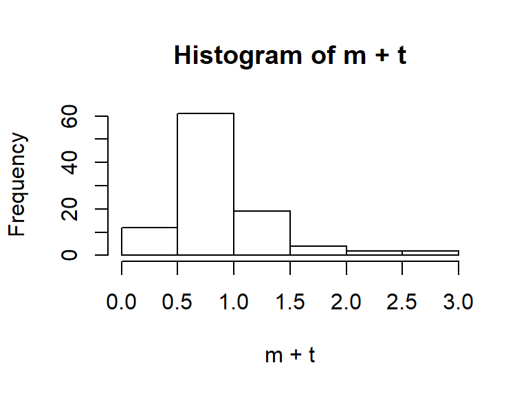

```r
hist(m+t)
```

## Command line exercises (5) (d)

Generate a vector **n** of 100 normally distributed values (mean = 0.5, SD = 0.15) such that **n** has a correlation of 0.7 with **m**. Add to **n** a new random vector **u** drawn from an exponential distribution with mean 0.8.

```r
n <- rnorm(100, .5, .15) * sqrt(1.0-0.7^2) + m*0.7
u <- rexp(100, 1/.8)
```

## Command line exercises (5) (e)

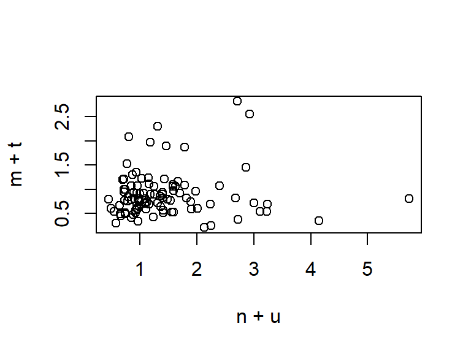

```r
plot(n+u,m+t)
```